# Can we trust the result?

Publication bias, robustness and sensitivity

Damien Beillouin

CIRAD, UPR HortSys

## Learning objectives

By the end of this session, you will be able to:

1. List the ways a set of studies can be a **biased sample** of the evidence.
2. Read a **contour-enhanced funnel plot** — and explain why asymmetry ≠ publication bias.
3. Test for small-study effects and time-lag bias **with dependent effect sizes**, and know which classic methods to avoid.
4. Run **sensitivity analyses** (leave-one-study-out, influence, study quality) and report robustness.

## Are our 28 studies a fair sample?

A meta-analysis assumes the studies it contains are **representative** of all studies done.

But studies with **significant** results are more likely to be:

- **published** → *publication bias*
- published **quickly** → *time-lag bias*
- published **in English** → *language bias*
- published **more than once** → *multiple-publication bias*
- **cited** (and found) → *citation bias*

The consequence The pooled effect can be **overestimated** — sometimes an effect appears where there is none.

The best cure is prevention Search grey literature, theses, reports and non-English studies (Monday’s sessions). The tests we see today can only **detect** and **probe** bias — never repair it.

Adapted from Ouédraogo (2024); see also Koricheva et al. (2013), chap. 14.

# Publication bias

## The logic of the funnel plot

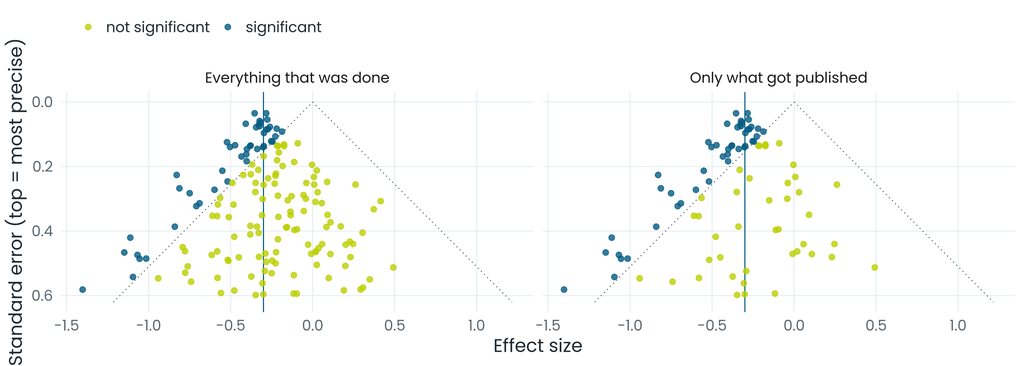

Large studies (top) cluster near the true effect; small ones (bottom) scatter **symmetrically** → a funnel.

*Where would the missing studies be?*  
Small **non-significant** studies (between the dotted lines) stay in drawers → a corner is **missing**.

## Our funnel, with significance contours

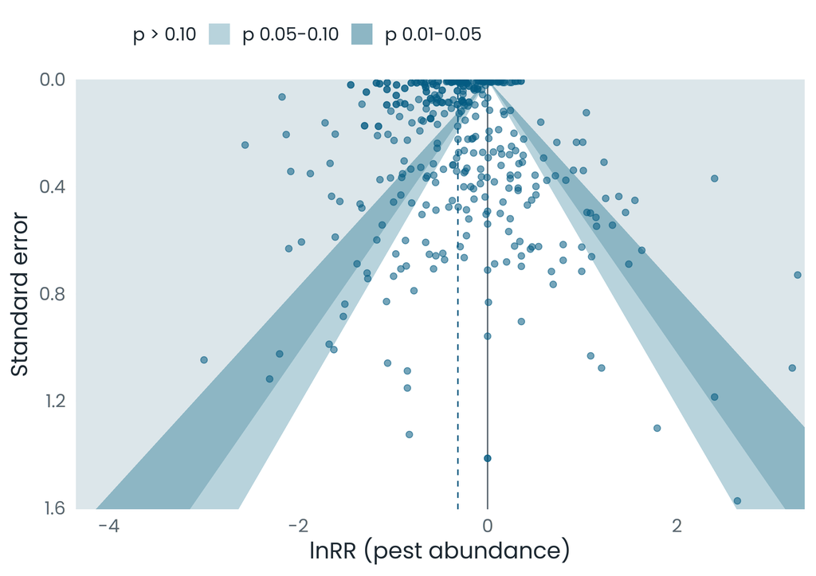

- Shaded bands: significance of each comparison (grey background: *p* < 0.01)
- Dashed line: the multilevel mean
- Top: 83 comparisons from 2 studies with SE < 0.02 — suspiciously precise: check the extraction

If missing studies were in the **white** zone (non-significant), publication bias is a plausible cause. If they would sit in significant zones, look for other causes (Peters et al. 2008).

## Asymmetry ≠ publication bias

Your call

Our funnel is asymmetric. List **other reasons** than publication bias.

- **Heterogeneity**: small studies differ (other crops, pests, methods) — true small-study effects.
- **Artefacts**: the variance of lnRR depends on the mean; extraction errors; pseudo-replication.
- **Chance**: with few studies, funnels are often asymmetric.

## Testing for small-study effects: the classic way

**Egger’s test** (Egger et al. 1997): regress each effect size on its standard error. A slope ≠ 0 means small studies give different results.

Our pests: *p* = 0.00037.

Two problems

1. It treats our 382 comparisons as **independent** — they come from 28 studies.
2. For lnRR, the SE is computed **from the means themselves** → an artificial link between effect and SE, even without any bias.

## Testing for small-study effects: the multilevel way

Add a precision measure as a **moderator** of the multilevel model (Nakagawa et al. 2022), based on **sample size only**:

$$\sqrt{1/n_T + 1/n_C}$$

```r
rma.mv(yi, vi,
       mods = ~ sqrt(1/n_t + 1/n_c),
       random = ~ 1 | study_id / es_id,
       test = "t", dfs = "contain",
       data = dat)
```

| Precision measure | Slope *p* |
| --- | --- |
| SE (artefact-prone) | 0.018 |
| $\sqrt{1/n_T + 1/n_C}$ | **0.10** |
| same, cluster-robust (CR2) | 0.18 |

With the recommended measure: **no robust evidence** of a small-study effect.

## If there were bias, would the conclusion change?

| Estimate | Pest abundance [95% CI] |
| --- | --- |
| Main model | -27% [-40; -11] |
| **PET**: effect of an infinitely large study | -43% [-61; -18] |
| **PEESE** | -36% [-50; -16] |

Rule (Stanley and Doucouliagos 2014): if the PET intercept is significant (here yes), report **PEESE**.

Adjusted estimates are, if anything, **stronger**: the pest reduction is **not** an artefact of publication bias.

With strong heterogeneity, PET-PEESE tends to **over-correct**: treat it as a sensitivity check, not as “the true effect”. Alternative: **selection models** [Vevea and Hedges (1995); `selmodel()` in metafor], which model the probability of publication given the p-value.

## Time-lag bias

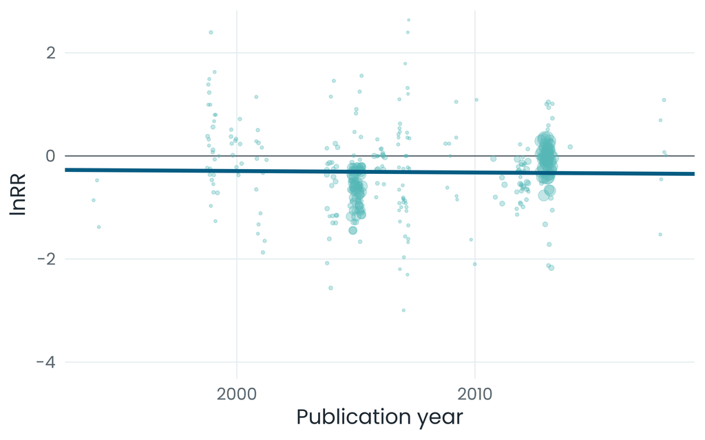

Do early studies report stronger effects than later ones?

**Year as a moderator** in the multilevel model: slope = -0.0029 per year (*p* = 0.87).

**No evidence** of a decline effect — with only 28 studies, the test has little power.

Also possible: include year and SE together (Nakagawa et al. 2022).

## Two classics to avoid (or to use with care)

Fail-safe N (Rosenthal) “How many null studies would make the result non-significant?”

Our data: **4,098,124** studies.

Meaningless: assumes missing studies have zero effect, ignores heterogeneity and dependence, estimates no bias. **Do not report it.**

Trim-and-fill Imputes “missing” studies to make the funnel symmetric.

Assumes asymmetry = publication bias, performs badly with heterogeneity, ignores dependence.  
→ at most a **sensitivity analysis** on study-level data, never “the corrected effect”.

Source: Nakagawa et al. (2022); Ouédraogo (2024).

# Robustness

## Does one study drive the result?

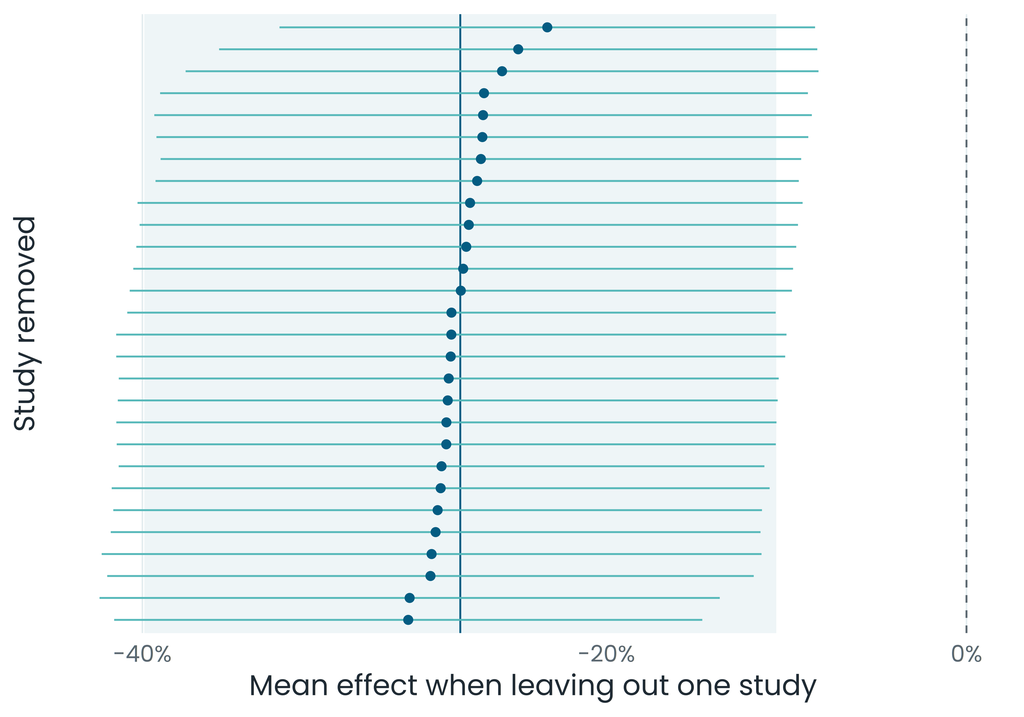

**Leave-one-*study*-out**: refit the model 28 times, dropping one whole study each time.

- Mean ranges from **-29%** to **-23%**
- The CI never crosses 0

**Cook’s distance** by study: largest = 0.32, no study stands out from the others.

The conclusion does not depend on any single study.

## A robustness table for your paper

| Analysis | Pest abundance | Conclusion changes? |
| --- | --- | --- |
| Main multilevel model (28 studies) | **-27%** [-40; -11] | — |
| Only comparisons meeting all validity criteria† (13 studies; 130 comparisons not appraisable) | -27% [-39; -13]; validity as moderator *p* = 0.74 | No |
| Leave-one-study-out (range of means) | -29% to -23% | No |
| Small-study effect (sample-size based) | slope *p* = 0.10; PEESE -36% | No |
| Time-lag (year as moderator) | slope ≈ 0 (*p* = 0.87) | No (low power) |

† Critical appraisal coded by Jones et al. (2021): enough sampling units in both groups, plots in their state long enough, intervention and comparator < 1.1 km apart. This is **internal validity** of each study (risk of bias, cf. CEE critical appraisal) — a different question from publication bias.

Also worth testing: another effect-size metric, the imputation of missing SDs, the correlation ρ assumed within studies. Report **all** sensitivity analyses — including those that change the result.

## Practical · 33 min + debrief

| Time | Task |
| --- | --- |
| 15:22 | Contour-enhanced **funnel plot** (code given: interpret) |
| 15:27 | Classic vs **multilevel Egger** (the lnRR trap); PET-PEESE |
| 15:37 | **Sensitivity**: leave-one-study-out, validity |
| 15:47 | *Your turn*: natural enemies — or the optional parts (time-lag, Cook, fail-safe N) |
| 15:55 | **Debrief** (all together) |

Open **`meta_analysis_course.Rproj`** (the course kit), then **`td_bias.R`**. Instructions and folded solutions: the practical web page.

## Key messages

1. Bias is best **prevented** by the search, not corrected by statistics.
2. **Asymmetry ≠ publication bias**: read the direction, use contour-enhanced funnels.
3. With several effect sizes per study, use **multilevel** tests — for lnRR with a **sample-size-based** precision; drop fail-safe N.
4. Report a **robustness table**: leave-one-study-out, influence, study quality, analytical choices.

## In the online notebook

Each point of this session developed further, with the same data, more pitfalls and exercises with solutions:

- [Publication bias and sensitivity](https://literaturesynthesis.github.io/notebook/chapters/publication-bias.html)
- [Data extraction and critical appraisal](https://literaturesynthesis.github.io/notebook/chapters/extraction-appraisal.html)
- [Reading a meta-analysis critically](https://literaturesynthesis.github.io/notebook/chapters/critical-reading.html)

**literaturesynthesis.github.io/notebook**

## References

Egger, M., G. Davey Smith, M. Schneider, and C. Minder. 1997. [Bias in meta-analysis detected by a simple, graphical test](https://doi.org/10.1136/bmj.315.7109.629). BMJ 315:629–634.

Jones, S. K., A. C. Sánchez, S. D. Juventia, and N. Estrada-Carmona. 2021. [A global database of diversified farming effects on biodiversity and yield](https://doi.org/10.1038/s41597-021-01000-y). Scientific Data 8:212.

Koricheva, J., J. Gurevitch, and K. Mengersen, editors. 2013. Handbook of meta-analysis in ecology and evolution. Princeton University Press, Princeton.

Nakagawa, S., M. Lagisz, M. D. Jennions, J. Koricheva, D. W. A. Noble, T. H. Parker, A. Sánchez-Tójar, Y. Yang, and R. E. O’Dea. 2022. [Methods for testing publication bias in ecological and evolutionary meta-analyses](https://doi.org/10.1111/2041-210X.13724). Methods in Ecology and Evolution 13:4–21.

Ouédraogo, D.-Y. 2024. Risks of bias in meta-analyses. Lecture, FRB-CESAB training course on meta-analyses and systematic reviews.

Peters, J. L., A. J. Sutton, D. R. Jones, K. R. Abrams, and L. Rushton. 2008. [Contour-enhanced meta-analysis funnel plots help distinguish publication bias from other causes of asymmetry](https://doi.org/10.1016/j.jclinepi.2007.11.010). Journal of Clinical Epidemiology 61:991–996.

Stanley, T. D., and H. Doucouliagos. 2014. [Meta-regression approximations to reduce publication selection bias](https://doi.org/10.1002/jrsm.1095). Research Synthesis Methods 5:60–78.

Vevea, J. L., and L. V. Hedges. 1995. [A general linear model for estimating effect size in the presence of publication bias](https://doi.org/10.1007/BF02294384). Psychometrika 60:419–435.

Viechtbauer, W., and M. W.-L. Cheung. 2010. [Outlier and influence diagnostics for meta-analysis](https://doi.org/10.1002/jrsm.11). Research Synthesis Methods 1:112–125.